# Randomization & Boostrapping - Intro to Statistical Inference

February 17, 2021

## Recall: Sampling Variability

Visualize the effect of sampling variation on the distribution of **any** point estimate – in this case, the sample slope

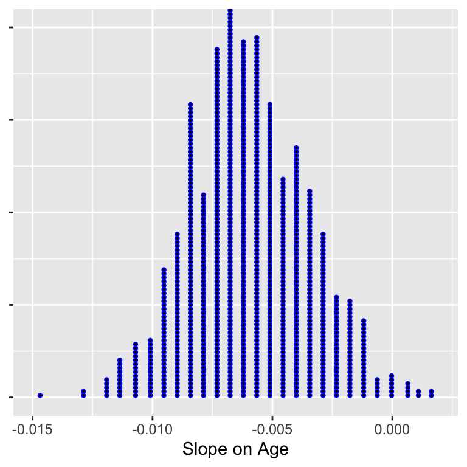

## Statistical Inference

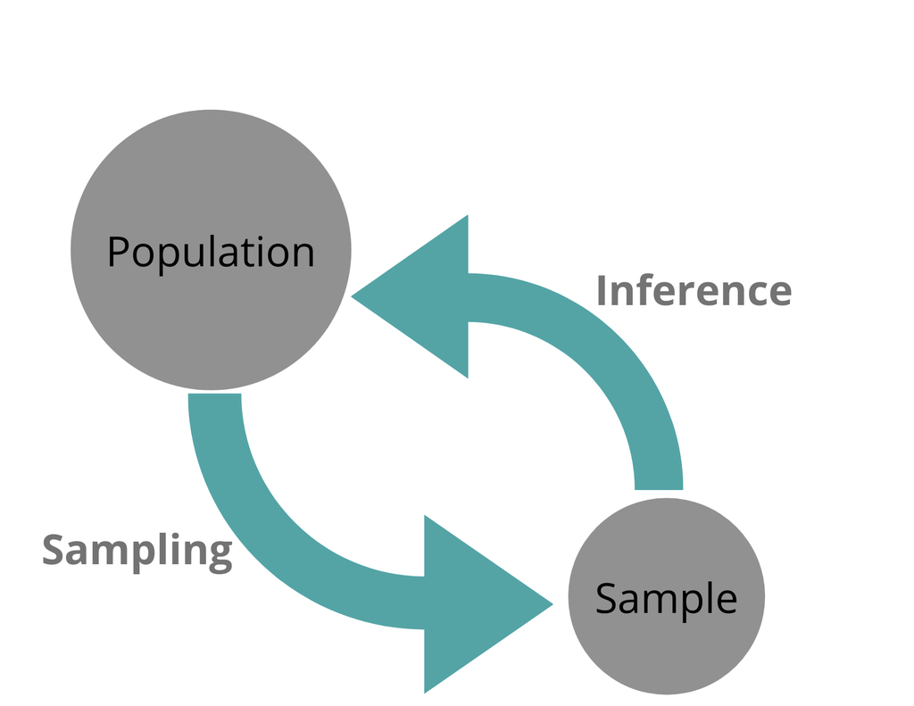

## Using Sampling Variability for Statistical Inference

We will use the idea of sampling variability for statistical inference in two ways.

1. To make a “null” distribution

*Generate samples we would have expected to see if the null hypothesis was true.*

1. To make a “bootstrap” distribution

*Generate other samples we would have collected, assuming our sample is representative of the population.*

## Difference in Means

An instructor decided to run two slight variations of the same exam. Prior to passing out the exams, she shuffled the exams together to ensure each student received a random version.

Anticipating complaints from students who took Version B, she would like to evaluate whether the difference observed in the groups is so large that it provides convincing evidence that Version B was more difficult (on average) than Version A.

**Construct hypotheses to evaluate whether the observed difference in sample means, \(\bar{x}_A - \bar{x}_B = 3.1\), is due to chance.**

(We will later evaluate these hypotheses using \(\alpha = 0.01\).)

## Observed data

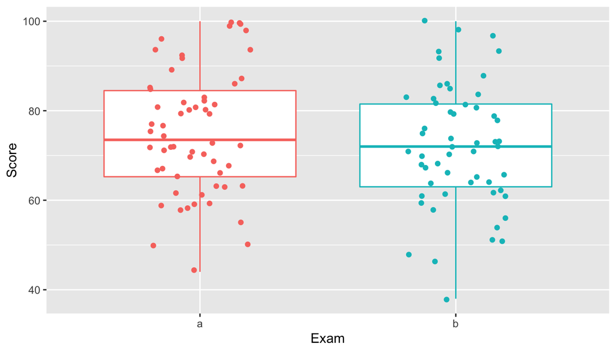

**Do you believe that exam B was more difficult than exam A?**

## Summary Statistics

Summary statistics of scores for each exam version.

|  | \(n\) | \(\bar{x}\) | s | minimum | maximum |
| --- | --- | --- | --- | --- | --- |
| A | 58 | 75.1 | 13.9 | 44 | 100 |
| B | 55 | 72.0 | 13.8 | 38 | 100 |

**Do you believe that exam B was more difficult than exam A?**

## Population Parameter

- A **parameter** is the “true” value of interest.
- We estimate the parameter using a point estimate from a sample of data.

**What would our parameter be in this example?**

## Randomization & Variability

A randomized experiment is done to assess whether or not one variable (the explanatory variable) causes changes in a second variable (the response variable).

- Is variability due to the causal mechanism (the randomized explanatory variable)?
- Or is it instead natural variability inherent to the data?
- To decide what is the source of the variability, we set-up a sham experiment.

## Randomization Distributions – Sham Experiments

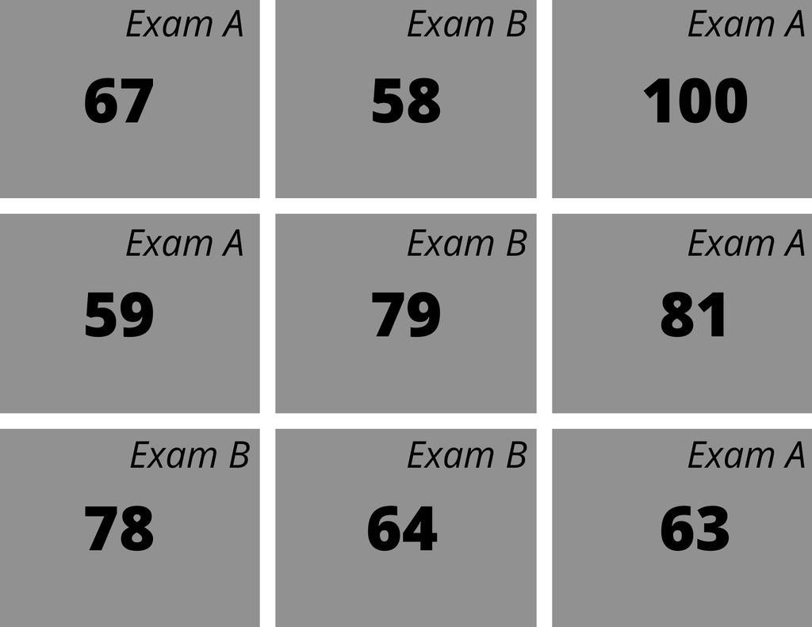

## The Role of the Null Hypothesis

- The shuffling process assumes the null hypothesis is true – that there is no effect of the treatment
  - In this example, the null hypothesis is that exam A and exam B are equally difficult.
  - We expect that students’ score on each exam should represent their true ability on that material – it shouldn’t matter which exam they took.

**If the null hypothesis is true, what is the expected value for \(\mu_A - \mu_B\)?**

## Shuffling the Data

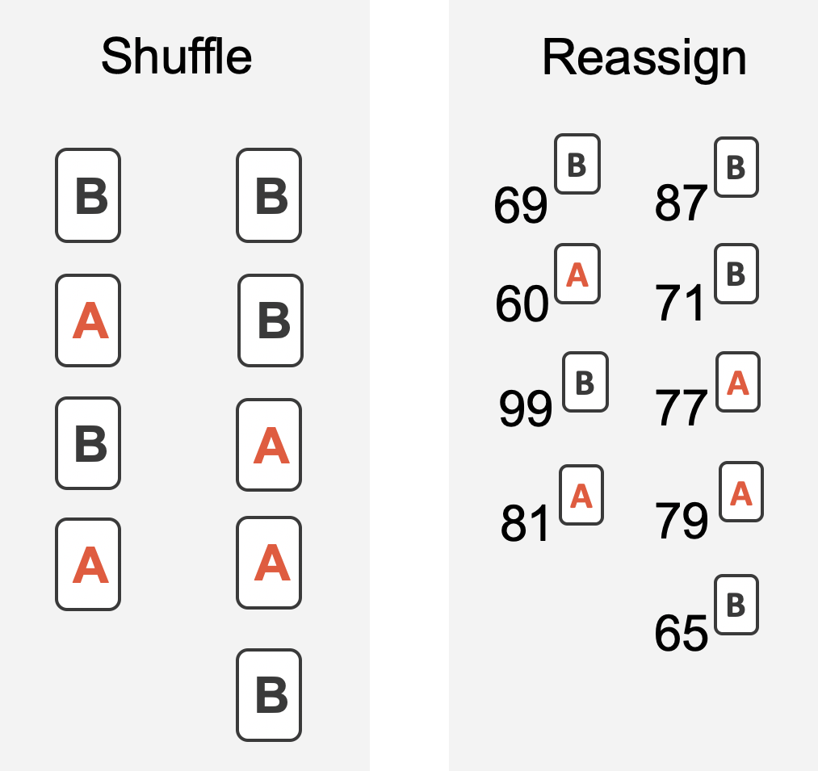

## Building a Null Distribution

- For every shuffle, we calculate the re-randomized difference in means (\(\bar{x}_A - \bar{x}_B\)).
- A distribution of these statistics gives us an idea of the variability we’d expect to happen just by chance, *if the null hypothesis is true*.

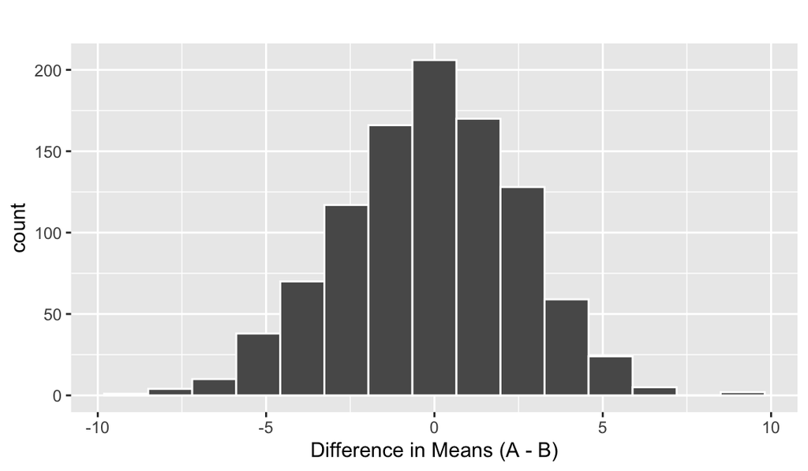

## Calculating the p-value

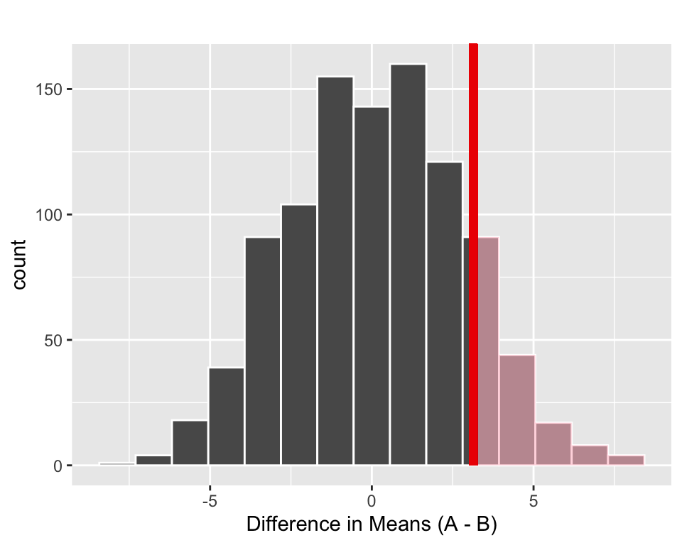

**Does our observed statistic seem unlikely to have occurred if the exams were equally difficult?**

## Making a Decision

```r
null %>%
  get_p_value(obs_stat = obs_diff, direction = "greater")
```

```
## [1] 0.132
```

- We specified that we would use \(\alpha = 0.01\).
- Since the p-value is larger than \(\alpha\), we do not reject the null hypothesis.
- We conclude that the data do not provide convincing evidence that exam B is more difficult than exam A.

**Is this the same as proving that exam A and exam B are equally difficult?**

## Confidence Intervals

- Hypothesis tests provide “yes” or “no” answers.
- Confidence intervals provide “how much” answers.
  - In this scenario, we are instead interested in estimating the unknown value of a population parameter.
- For this example, a confidence interval can be used to the range of values that seem plausible for the difference in the mean exam scores (\(\mu_A - \mu_B\)).

## Bootstraps & Variability

- As with randomization tests, our goal with bootstrapping is to understand variability of a statistic.
- Unlike randomization tests, the bootstrap models how a statistic changes from repeated sampling.
- How a statistic varies from sample to sample will provide information about how different a statistic is from the parameter of interest.

## Obtaining New Samples

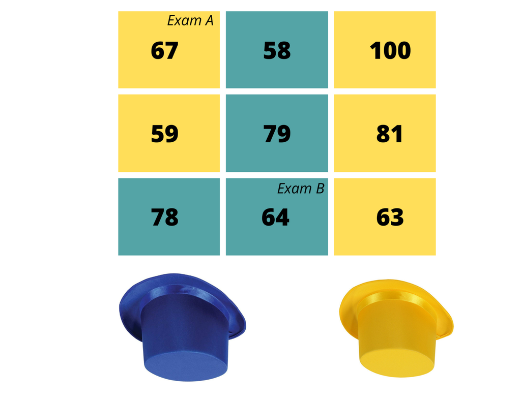

## Assumptions Behind a Bootstrap

- Here, we are assuming that the scores earned on the exam are representative of the population of all scores students may have earned on these exams.
- The process of bootstrapping is applied to *each* group separately.
  - This assumes the exam scores for each group are representative of all possible scores students would have earned on each exam.

## Creating a Bootstrap Distribution

- For every resample, we calculate the difference in means: \(\bar{x}_A - \bar{x}_B\)
- A distribution of these statistics gives us an idea of the variability we’d expect in repeated samples from the population.

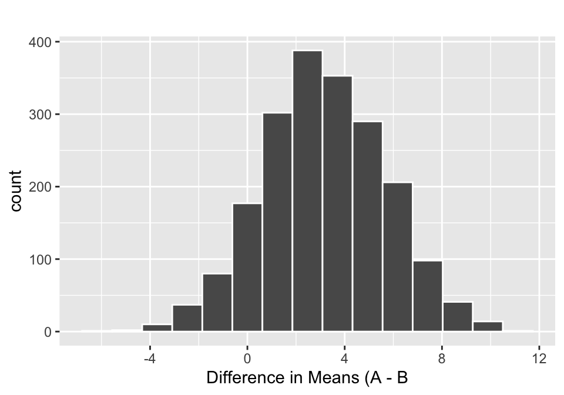

## Calculating a Confidence Interval

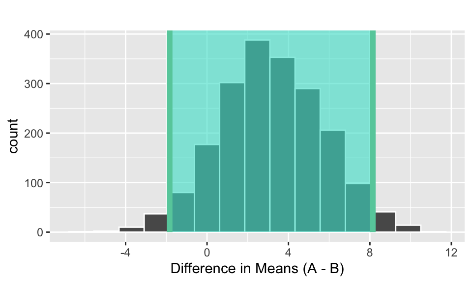

```r
boot %>%
  get_confidence_interval(level = 0.95)
```

```
## # A tibble: 1 x 2
##   lower_ci upper_ci
##      <dbl>    <dbl>
## 1    -1.84     8.14
```

## Interpretting a Confidence Interval

The confidence interval was calculated to be (-1.84, 8.14).

- **What parameter are we 95% confident lies in this interval?**
- **If we were to construct 100 of these 95% confidence intervals, how many would we expect to capture this parameter?**
- **So, what does saying we’re “95% confident” mean?**